# Statistics Exercise on Beer Ratings

## Report

The craft beer data set contained 5558 records of beer, their name, types, manufacturing brewery along with measures such as ABV value and flavours. After going through the data in detail, no missing entries were found however couple of records did not contain names and this has to be updated going forward.

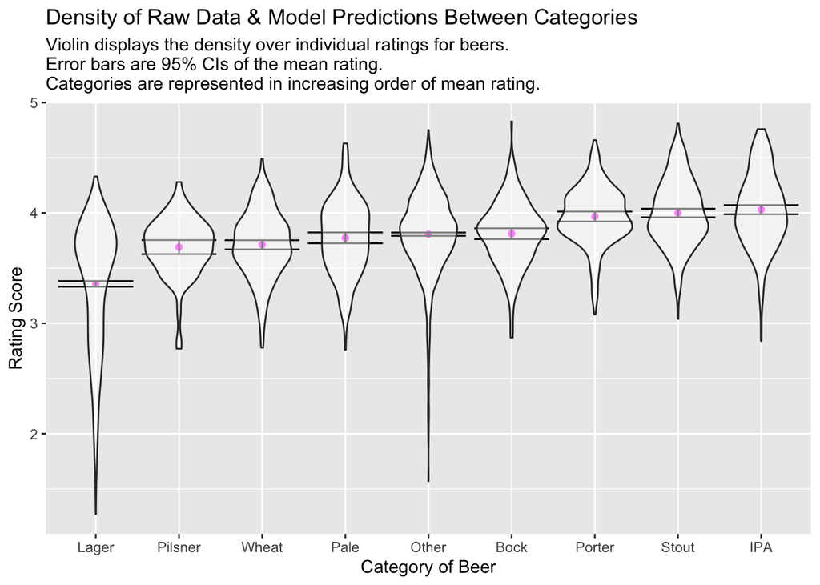

The above plot shows us the calculated mean rating and CIs for each category of beer. It can be inferred from the plot that the CIs for each category are very narrow and hence we can be confident about our model’s estimated mean rating for each category. It can further be inferred that the Lager category of beers have the lowest mean rating whereas the IPA category has the highest. The plot also shows us the density of raw data across categories and thus it can noticed that Lager & Other category of beer has the largest variance in ratings, whereas the ratings for other categories is densely populated between the 3.5 – 4.5 rating value.

In conclusion, given the variance of raw data and the difference in mean rating across categories, it can be said that beer category is a significant predictor of the rating of beer.